# Risk Factor Analysis

## Outcome Variable

**Outcome Variable:** wasted

## Predictor Variables

**Intervention Variable:** sex

**Adjustment Set:**

unadjusted

## Stratifying Variables

The analysis was stratified on these variable(s):

- agecat
- studyid
- country

## Data Summary

| agecat | studyid | country | sex | wasted | n_cell | n |
| --- | --- | --- | --- | --- | --- | --- |
| Birth | ki0047075b-MAL-ED | BANGLADESH | Female | 0 | 98 | 241 |
| Birth | ki0047075b-MAL-ED | BANGLADESH | Female | 1 | 21 | 241 |
| Birth | ki0047075b-MAL-ED | BANGLADESH | Male | 0 | 103 | 241 |
| Birth | ki0047075b-MAL-ED | BANGLADESH | Male | 1 | 19 | 241 |
| Birth | ki0047075b-MAL-ED | BRAZIL | Female | 0 | 84 | 183 |
| Birth | ki0047075b-MAL-ED | BRAZIL | Female | 1 | 2 | 183 |
| Birth | ki0047075b-MAL-ED | BRAZIL | Male | 0 | 93 | 183 |
| Birth | ki0047075b-MAL-ED | BRAZIL | Male | 1 | 4 | 183 |
| Birth | ki0047075b-MAL-ED | INDIA | Female | 0 | 88 | 203 |
| Birth | ki0047075b-MAL-ED | INDIA | Female | 1 | 20 | 203 |
| Birth | ki0047075b-MAL-ED | INDIA | Male | 0 | 82 | 203 |
| Birth | ki0047075b-MAL-ED | INDIA | Male | 1 | 13 | 203 |
| Birth | ki0047075b-MAL-ED | NEPAL | Female | 0 | 68 | 168 |
| Birth | ki0047075b-MAL-ED | NEPAL | Female | 1 | 14 | 168 |
| Birth | ki0047075b-MAL-ED | NEPAL | Male | 0 | 80 | 168 |
| Birth | ki0047075b-MAL-ED | NEPAL | Male | 1 | 6 | 168 |
| Birth | ki0047075b-MAL-ED | PERU | Female | 0 | 125 | 279 |
| Birth | ki0047075b-MAL-ED | PERU | Female | 1 | 2 | 279 |
| Birth | ki0047075b-MAL-ED | PERU | Male | 0 | 148 | 279 |
| Birth | ki0047075b-MAL-ED | PERU | Male | 1 | 4 | 279 |
| Birth | ki0047075b-MAL-ED | SOUTH AFRICA | Female | 0 | 119 | 258 |
| Birth | ki0047075b-MAL-ED | SOUTH AFRICA | Female | 1 | 9 | 258 |
| Birth | ki0047075b-MAL-ED | SOUTH AFRICA | Male | 0 | 121 | 258 |
| Birth | ki0047075b-MAL-ED | SOUTH AFRICA | Male | 1 | 9 | 258 |
| Birth | ki0047075b-MAL-ED | TANZANIA, UNITED REPUBLIC OF | Female | 0 | 57 | 118 |
| Birth | ki0047075b-MAL-ED | TANZANIA, UNITED REPUBLIC OF | Female | 1 | 1 | 118 |
| Birth | ki0047075b-MAL-ED | TANZANIA, UNITED REPUBLIC OF | Male | 0 | 59 | 118 |
| Birth | ki0047075b-MAL-ED | TANZANIA, UNITED REPUBLIC OF | Male | 1 | 1 | 118 |
| Birth | ki1000108-CMC-V-BCS-2002 | INDIA | Female | 0 | 37 | 88 |
| Birth | ki1000108-CMC-V-BCS-2002 | INDIA | Female | 1 | 9 | 88 |

[output cut: 314 more lines]

The following strata were considered:

- agecat: 24 months, studyid: ki0047075b-MAL-ED, country: BANGLADESH
- agecat: 24 months, studyid: ki0047075b-MAL-ED, country: BRAZIL
- agecat: 24 months, studyid: ki0047075b-MAL-ED, country: INDIA
- agecat: 24 months, studyid: ki0047075b-MAL-ED, country: NEPAL
- agecat: 24 months, studyid: ki0047075b-MAL-ED, country: PERU
- agecat: 24 months, studyid: ki0047075b-MAL-ED, country: SOUTH AFRICA
- agecat: 24 months, studyid: ki0047075b-MAL-ED, country: TANZANIA, UNITED REPUBLIC OF
- agecat: 24 months, studyid: ki1000108-CMC-V-BCS-2002, country: INDIA
- agecat: 24 months, studyid: ki1000108-IRC, country: INDIA
- agecat: 24 months, studyid: ki1017093-NIH-Birth, country: BANGLADESH
- agecat: 24 months, studyid: ki1017093b-PROVIDE, country: BANGLADESH
- agecat: 24 months, studyid: ki1017093c-NIH-Crypto, country: BANGLADESH
- agecat: 24 months, studyid: ki1066203-TanzaniaChild2, country: TANZANIA, UNITED REPUBLIC OF
- agecat: 24 months, studyid: ki1101329-Keneba, country: GAMBIA
- agecat: 24 months, studyid: ki1113344-GMS-Nepal, country: NEPAL
- agecat: 24 months, studyid: ki1114097-CMIN, country: BANGLADESH
- agecat: 24 months, studyid: ki1114097-CMIN, country: GUINEA-BISSAU
- agecat: 24 months, studyid: ki1114097-CMIN, country: PERU
- agecat: 24 months, studyid: ki1114097-CONTENT, country: PERU
- agecat: 24 months, studyid: ki1119695-PROBIT, country: BELARUS
- agecat: 24 months, studyid: ki1126311-ZVITAMBO, country: ZIMBABWE
- agecat: 24 months, studyid: ki1135781-COHORTS, country: GUATEMALA
- agecat: 24 months, studyid: ki1135781-COHORTS, country: INDIA
- agecat: 24 months, studyid: ki1135781-COHORTS, country: PHILIPPINES
- agecat: 24 months, studyid: ki1148112-LCNI-5, country: MALAWI
- agecat: 24 months, studyid: kiGH5241-JiVitA-3, country: BANGLADESH
- agecat: 24 months, studyid: kiGH5241-JiVitA-4, country: BANGLADESH
- agecat: 6 months, studyid: ki0047075b-MAL-ED, country: BANGLADESH
- agecat: 6 months, studyid: ki0047075b-MAL-ED, country: BRAZIL
- agecat: 6 months, studyid: ki0047075b-MAL-ED, country: INDIA
- agecat: 6 months, studyid: ki0047075b-MAL-ED, country: NEPAL
- agecat: 6 months, studyid: ki0047075b-MAL-ED, country: PERU
- agecat: 6 months, studyid: ki0047075b-MAL-ED, country: SOUTH AFRICA
- agecat: 6 months, studyid: ki0047075b-MAL-ED, country: TANZANIA, UNITED REPUBLIC OF
- agecat: 6 months, studyid: ki1000108-CMC-V-BCS-2002, country: INDIA
- agecat: 6 months, studyid: ki1000108-IRC, country: INDIA
- agecat: 6 months, studyid: ki1000109-EE, country: PAKISTAN
- agecat: 6 months, studyid: ki1000109-ResPak, country: PAKISTAN
- agecat: 6 months, studyid: ki1000304b-SAS-CompFeed, country: INDIA
- agecat: 6 months, studyid: ki1000304b-SAS-FoodSuppl, country: INDIA
- agecat: 6 months, studyid: ki1017093-NIH-Birth, country: BANGLADESH
- agecat: 6 months, studyid: ki1017093b-PROVIDE, country: BANGLADESH
- agecat: 6 months, studyid: ki1017093c-NIH-Crypto, country: BANGLADESH
- agecat: 6 months, studyid: ki1066203-TanzaniaChild2, country: TANZANIA, UNITED REPUBLIC OF
- agecat: 6 months, studyid: ki1101329-Keneba, country: GAMBIA
- agecat: 6 months, studyid: ki1112895-Guatemala BSC, country: GUATEMALA
- agecat: 6 months, studyid: ki1113344-GMS-Nepal, country: NEPAL
- agecat: 6 months, studyid: ki1114097-CMIN, country: BANGLADESH
- agecat: 6 months, studyid: ki1114097-CMIN, country: BRAZIL
- agecat: 6 months, studyid: ki1114097-CMIN, country: GUINEA-BISSAU
- agecat: 6 months, studyid: ki1114097-CMIN, country: PERU
- agecat: 6 months, studyid: ki1114097-CONTENT, country: PERU
- agecat: 6 months, studyid: ki1119695-PROBIT, country: BELARUS
- agecat: 6 months, studyid: ki1126311-ZVITAMBO, country: ZIMBABWE
- agecat: 6 months, studyid: ki1135781-COHORTS, country: GUATEMALA
- agecat: 6 months, studyid: ki1135781-COHORTS, country: INDIA
- agecat: 6 months, studyid: ki1135781-COHORTS, country: PHILIPPINES
- agecat: 6 months, studyid: ki1148112-LCNI-5, country: MALAWI
- agecat: 6 months, studyid: kiGH5241-JiVitA-3, country: BANGLADESH
- agecat: 6 months, studyid: kiGH5241-JiVitA-4, country: BANGLADESH
- agecat: Birth, studyid: ki0047075b-MAL-ED, country: BANGLADESH
- agecat: Birth, studyid: ki0047075b-MAL-ED, country: BRAZIL
- agecat: Birth, studyid: ki0047075b-MAL-ED, country: INDIA
- agecat: Birth, studyid: ki0047075b-MAL-ED, country: NEPAL
- agecat: Birth, studyid: ki0047075b-MAL-ED, country: PERU
- agecat: Birth, studyid: ki0047075b-MAL-ED, country: SOUTH AFRICA
- agecat: Birth, studyid: ki0047075b-MAL-ED, country: TANZANIA, UNITED REPUBLIC OF
- agecat: Birth, studyid: ki1000108-CMC-V-BCS-2002, country: INDIA
- agecat: Birth, studyid: ki1000108-IRC, country: INDIA
- agecat: Birth, studyid: ki1000109-EE, country: PAKISTAN
- agecat: Birth, studyid: ki1000109-ResPak, country: PAKISTAN
- agecat: Birth, studyid: ki1000304b-SAS-CompFeed, country: INDIA
- agecat: Birth, studyid: ki1017093-NIH-Birth, country: BANGLADESH
- agecat: Birth, studyid: ki1017093c-NIH-Crypto, country: BANGLADESH
- agecat: Birth, studyid: ki1101329-Keneba, country: GAMBIA
- agecat: Birth, studyid: ki1114097-CMIN, country: BANGLADESH
- agecat: Birth, studyid: ki1114097-CMIN, country: BRAZIL
- agecat: Birth, studyid: ki1114097-CMIN, country: PERU
- agecat: Birth, studyid: ki1114097-CONTENT, country: PERU
- agecat: Birth, studyid: ki1119695-PROBIT, country: BELARUS
- agecat: Birth, studyid: ki1126311-ZVITAMBO, country: ZIMBABWE
- agecat: Birth, studyid: ki1135781-COHORTS, country: GUATEMALA
- agecat: Birth, studyid: ki1135781-COHORTS, country: INDIA
- agecat: Birth, studyid: ki1135781-COHORTS, country: PHILIPPINES
- agecat: Birth, studyid: kiGH5241-JiVitA-3, country: BANGLADESH
- agecat: Birth, studyid: kiGH5241-JiVitA-4, country: BANGLADESH

### Dropped Strata

Some strata were dropped due to rare outcomes:

- agecat: Birth, studyid: ki0047075b-MAL-ED, country: BRAZIL
- agecat: Birth, studyid: ki0047075b-MAL-ED, country: PERU
- agecat: Birth, studyid: ki0047075b-MAL-ED, country: TANZANIA, UNITED REPUBLIC OF
- agecat: Birth, studyid: ki1000109-EE, country: PAKISTAN
- agecat: Birth, studyid: ki1000109-ResPak, country: PAKISTAN
- agecat: Birth, studyid: ki1017093-NIH-Birth, country: BANGLADESH
- agecat: Birth, studyid: ki1017093c-NIH-Crypto, country: BANGLADESH
- agecat: Birth, studyid: ki1114097-CMIN, country: BANGLADESH
- agecat: Birth, studyid: ki1114097-CMIN, country: BRAZIL
- agecat: Birth, studyid: ki1114097-CMIN, country: PERU
- agecat: Birth, studyid: ki1114097-CONTENT, country: PERU
- agecat: 6 months, studyid: ki0047075b-MAL-ED, country: BANGLADESH
- agecat: 6 months, studyid: ki0047075b-MAL-ED, country: BRAZIL
- agecat: 6 months, studyid: ki0047075b-MAL-ED, country: NEPAL
- agecat: 6 months, studyid: ki0047075b-MAL-ED, country: PERU
- agecat: 6 months, studyid: ki0047075b-MAL-ED, country: SOUTH AFRICA
- agecat: 6 months, studyid: ki0047075b-MAL-ED, country: TANZANIA, UNITED REPUBLIC OF
- agecat: 6 months, studyid: ki1112895-Guatemala BSC, country: GUATEMALA
- agecat: 6 months, studyid: ki1114097-CMIN, country: BRAZIL
- agecat: 6 months, studyid: ki1114097-CMIN, country: PERU
- agecat: 6 months, studyid: ki1114097-CONTENT, country: PERU
- agecat: 24 months, studyid: ki0047075b-MAL-ED, country: BRAZIL
- agecat: 24 months, studyid: ki0047075b-MAL-ED, country: NEPAL
- agecat: 24 months, studyid: ki0047075b-MAL-ED, country: PERU
- agecat: 24 months, studyid: ki0047075b-MAL-ED, country: SOUTH AFRICA
- agecat: 24 months, studyid: ki0047075b-MAL-ED, country: TANZANIA, UNITED REPUBLIC OF
- agecat: 24 months, studyid: ki1066203-TanzaniaChild2, country: TANZANIA, UNITED REPUBLIC OF
- agecat: 24 months, studyid: ki1114097-CMIN, country: PERU
- agecat: 24 months, studyid: ki1114097-CONTENT, country: PERU
- agecat: 24 months, studyid: ki1148112-LCNI-5, country: MALAWI

## Methods Detail

We’re interested in the causal parameters $E[Y_a]$ for all values of $a \in \mathcal{A}$. These parameters represent the mean outcome if, possibly contrary to fact, we intervened to set all units to have $A=a$. Under the randomization and positivity assumptions, these are identified by the statistical parameters $\psi_a=E_W[E_{Y|A,W}(Y|A=a,W)]$. In addition, we’re interested in the mean of $Y$, $E[Y]$ under no intervention (the observed mean). We will estimate these parameters by using SuperLearner to fit the relevant likelihood factors – $E_{Y|A,W}(Y|A=a,W)$ and $p(A=a|W)$, and then updating our likelihood fit using a joint TMLE.

For unadjusted analyses ($W=\{\}$), initial likelihoods were estimated using Lrnr_glm to estimate the simple $E(Y|A)$ and Lrnr_mean to estimate $p(A)$. For adjusted analyses, a small library containing Lrnr_glmnet, Lrnr_xgboost, and Lrnr_mean was used.

Having estimated these parameters, we will then use the delta method to estimate relative risks and attributable risks relative to a prespecified baseline level of $A$.

# Results Detail

## Results Plots

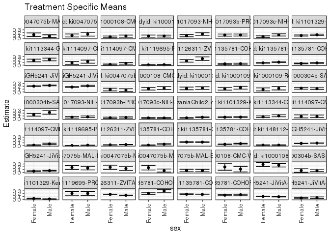

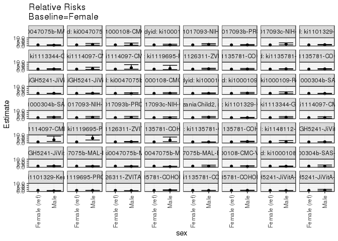

[figure not shown]

[figure not shown]

## Results Table

### Parameter: TSM

| agecat | studyid | country | intervention_level | baseline_level | estimate | ci_lower | ci_upper |
| --- | --- | --- | --- | --- | --- | --- | --- |
| Birth | ki0047075b-MAL-ED | BANGLADESH | Female | NA | 0.1764706 | 0.1078344 | 0.2451068 |
| Birth | ki0047075b-MAL-ED | BANGLADESH | Male | NA | 0.1557377 | 0.0912604 | 0.2202150 |
| Birth | ki0047075b-MAL-ED | INDIA | Female | NA | 0.1851852 | 0.1117438 | 0.2586266 |
| Birth | ki0047075b-MAL-ED | INDIA | Male | NA | 0.1368421 | 0.0675612 | 0.2061230 |
| Birth | ki0047075b-MAL-ED | NEPAL | Female | NA | 0.1707317 | 0.0890467 | 0.2524167 |
| Birth | ki0047075b-MAL-ED | NEPAL | Male | NA | 0.0697674 | 0.0157645 | 0.1237704 |
| Birth | ki0047075b-MAL-ED | SOUTH AFRICA | Female | NA | 0.0703125 | 0.0259341 | 0.1146909 |
| Birth | ki0047075b-MAL-ED | SOUTH AFRICA | Male | NA | 0.0692308 | 0.0255097 | 0.1129518 |
| Birth | ki1000108-CMC-V-BCS-2002 | INDIA | Female | NA | 0.1956522 | 0.0803559 | 0.3109484 |
| Birth | ki1000108-CMC-V-BCS-2002 | INDIA | Male | NA | 0.1190476 | 0.0205464 | 0.2175489 |
| Birth | ki1000108-IRC | INDIA | Female | NA | 0.2837838 | 0.2110448 | 0.3565227 |
| Birth | ki1000108-IRC | INDIA | Male | NA | 0.2564103 | 0.1950342 | 0.3177863 |
| Birth | ki1000304b-SAS-CompFeed | INDIA | Female | NA | 0.0704225 | 0.0075950 | 0.1332501 |
| Birth | ki1000304b-SAS-CompFeed | INDIA | Male | NA | 0.0631579 | 0.0304805 | 0.0958353 |
| Birth | ki1101329-Keneba | GAMBIA | Female | NA | 0.0272989 | 0.0151885 | 0.0394092 |
| Birth | ki1101329-Keneba | GAMBIA | Male | NA | 0.0123796 | 0.0043392 | 0.0204201 |
| Birth | ki1119695-PROBIT | BELARUS | Female | NA | 0.2097452 | 0.1449538 | 0.2745366 |
| Birth | ki1119695-PROBIT | BELARUS | Male | NA | 0.2080216 | 0.1412059 | 0.2748372 |
| Birth | ki1126311-ZVITAMBO | ZIMBABWE | Female | NA | 0.1758560 | 0.1663955 | 0.1853165 |
| Birth | ki1126311-ZVITAMBO | ZIMBABWE | Male | NA | 0.1442868 | 0.1358696 | 0.1527040 |
| Birth | ki1135781-COHORTS | GUATEMALA | Female | NA | 0.2083333 | 0.1663541 | 0.2503126 |
| Birth | ki1135781-COHORTS | GUATEMALA | Male | NA | 0.2954545 | 0.2504882 | 0.3404209 |
| Birth | ki1135781-COHORTS | INDIA | Female | NA | 0.1812331 | 0.1673360 | 0.1951302 |
| Birth | ki1135781-COHORTS | INDIA | Male | NA | 0.1730947 | 0.1600687 | 0.1861208 |
| Birth | ki1135781-COHORTS | PHILIPPINES | Female | NA | 0.1477941 | 0.1289292 | 0.1666590 |
| Birth | ki1135781-COHORTS | PHILIPPINES | Male | NA | 0.1624431 | 0.1440116 | 0.1808747 |
| Birth | kiGH5241-JiVitA-3 | BANGLADESH | Female | NA | 0.1015920 | 0.0944705 | 0.1087135 |
| Birth | kiGH5241-JiVitA-3 | BANGLADESH | Male | NA | 0.0907557 | 0.0839462 | 0.0975652 |
| Birth | kiGH5241-JiVitA-4 | BANGLADESH | Female | NA | 0.0477707 | 0.0239199 | 0.0716215 |
| Birth | kiGH5241-JiVitA-4 | BANGLADESH | Male | NA | 0.0569106 | 0.0279943 | 0.0858268 |

[output cut: 82 more lines]

### Parameter: E(Y)

| agecat | studyid | country | intervention_level | baseline_level | estimate | ci_lower | ci_upper |
| --- | --- | --- | --- | --- | --- | --- | --- |
| Birth | ki0047075b-MAL-ED | BANGLADESH | NA | NA | 0.1659751 | 0.1189041 | 0.2130461 |
| Birth | ki0047075b-MAL-ED | INDIA | NA | NA | 0.1625616 | 0.1116803 | 0.2134428 |
| Birth | ki0047075b-MAL-ED | NEPAL | NA | NA | 0.1190476 | 0.0699312 | 0.1681640 |
| Birth | ki0047075b-MAL-ED | SOUTH AFRICA | NA | NA | 0.0697674 | 0.0386213 | 0.1009135 |
| Birth | ki1000108-CMC-V-BCS-2002 | INDIA | NA | NA | 0.1590909 | 0.0822335 | 0.2359483 |
| Birth | ki1000108-IRC | INDIA | NA | NA | 0.2682216 | 0.2212677 | 0.3151755 |
| Birth | ki1000304b-SAS-CompFeed | INDIA | NA | NA | 0.0662651 | 0.0346192 | 0.0979109 |
| Birth | ki1101329-Keneba | GAMBIA | NA | NA | 0.0196767 | 0.0124580 | 0.0268954 |
| Birth | ki1119695-PROBIT | BELARUS | NA | NA | 0.2089120 | 0.1435514 | 0.2742726 |
| Birth | ki1126311-ZVITAMBO | ZIMBABWE | NA | NA | 0.1594921 | 0.1531776 | 0.1658066 |
| Birth | ki1135781-COHORTS | GUATEMALA | NA | NA | 0.2539683 | 0.2229196 | 0.2850169 |
| Birth | ki1135781-COHORTS | INDIA | NA | NA | 0.1769740 | 0.1674681 | 0.1864799 |
| Birth | ki1135781-COHORTS | PHILIPPINES | NA | NA | 0.1555709 | 0.1423748 | 0.1687670 |
| Birth | kiGH5241-JiVitA-3 | BANGLADESH | NA | NA | 0.0958686 | 0.0906699 | 0.1010673 |
| Birth | kiGH5241-JiVitA-4 | BANGLADESH | NA | NA | 0.0527086 | 0.0336587 | 0.0717585 |
| 6 months | ki0047075b-MAL-ED | INDIA | NA | NA | 0.0762712 | 0.0423347 | 0.1102077 |
| 6 months | ki1000108-CMC-V-BCS-2002 | INDIA | NA | NA | 0.1250000 | 0.0911644 | 0.1588356 |
| 6 months | ki1000108-IRC | INDIA | NA | NA | 0.1323529 | 0.0994307 | 0.1652752 |
| 6 months | ki1000109-EE | PAKISTAN | NA | NA | 0.1303191 | 0.0962457 | 0.1643926 |
| 6 months | ki1000109-ResPak | PAKISTAN | NA | NA | 0.1106383 | 0.0704470 | 0.1508296 |
| 6 months | ki1000304b-SAS-CompFeed | INDIA | NA | NA | 0.1244378 | 0.0992652 | 0.1496104 |
| 6 months | ki1000304b-SAS-FoodSuppl | INDIA | NA | NA | 0.1815789 | 0.1427684 | 0.2203895 |
| 6 months | ki1017093-NIH-Birth | BANGLADESH | NA | NA | 0.0634328 | 0.0427791 | 0.0840865 |
| 6 months | ki1017093b-PROVIDE | BANGLADESH | NA | NA | 0.0412371 | 0.0250690 | 0.0574052 |
| 6 months | ki1017093c-NIH-Crypto | BANGLADESH | NA | NA | 0.0293706 | 0.0169860 | 0.0417552 |
| 6 months | ki1066203-TanzaniaChild2 | TANZANIA, UNITED REPUBLIC OF | NA | NA | 0.0428994 | 0.0340782 | 0.0517206 |
| 6 months | ki1101329-Keneba | GAMBIA | NA | NA | 0.0579225 | 0.0479029 | 0.0679420 |
| 6 months | ki1113344-GMS-Nepal | NEPAL | NA | NA | 0.0905861 | 0.0668565 | 0.1143158 |
| 6 months | ki1114097-CMIN | BANGLADESH | NA | NA | 0.0864198 | 0.0510184 | 0.1218211 |
| 6 months | ki1114097-CMIN | GUINEA-BISSAU | NA | NA | 0.0400471 | 0.0268506 | 0.0532437 |
| 6 months | ki1119695-PROBIT | BELARUS | NA | NA | 0.0082503 | 0.0066012 | 0.0098994 |
| 6 months | ki1126311-ZVITAMBO | ZIMBABWE | NA | NA | 0.0320668 | 0.0282681 | 0.0358654 |
| 6 months | ki1135781-COHORTS | GUATEMALA | NA | NA | 0.0332295 | 0.0219033 | 0.0445557 |
| 6 months | ki1135781-COHORTS | INDIA | NA | NA | 0.1262774 | 0.1184108 | 0.1341439 |
| 6 months | ki1135781-COHORTS | PHILIPPINES | NA | NA | 0.0594974 | 0.0505830 | 0.0684118 |
| 6 months | ki1148112-LCNI-5 | MALAWI | NA | NA | 0.0166865 | 0.0080138 | 0.0253592 |
| 6 months | kiGH5241-JiVitA-3 | BANGLADESH | NA | NA | 0.0846640 | 0.0798626 | 0.0894653 |
| 6 months | kiGH5241-JiVitA-4 | BANGLADESH | NA | NA | 0.0569005 | 0.0480577 | 0.0657432 |
| 24 months | ki0047075b-MAL-ED | BANGLADESH | NA | NA | 0.0990566 | 0.0587480 | 0.1393652 |
| 24 months | ki0047075b-MAL-ED | INDIA | NA | NA | 0.1189427 | 0.0767376 | 0.1611478 |
| 24 months | ki1000108-CMC-V-BCS-2002 | INDIA | NA | NA | 0.0618280 | 0.0373207 | 0.0863352 |
| 24 months | ki1000108-IRC | INDIA | NA | NA | 0.0757946 | 0.0501131 | 0.1014762 |
| 24 months | ki1017093-NIH-Birth | BANGLADESH | NA | NA | 0.1238318 | 0.0925894 | 0.1550741 |
| 24 months | ki1017093b-PROVIDE | BANGLADESH | NA | NA | 0.1124567 | 0.0866788 | 0.1382347 |
| 24 months | ki1017093c-NIH-Crypto | BANGLADESH | NA | NA | 0.0875486 | 0.0630907 | 0.1120065 |
| 24 months | ki1101329-Keneba | GAMBIA | NA | NA | 0.1106605 | 0.0958563 | 0.1254646 |
| 24 months | ki1113344-GMS-Nepal | NEPAL | NA | NA | 0.1827309 | 0.1487560 | 0.2167058 |
| 24 months | ki1114097-CMIN | BANGLADESH | NA | NA | 0.1028807 | 0.0646041 | 0.1411572 |
| 24 months | ki1114097-CMIN | GUINEA-BISSAU | NA | NA | 0.0417423 | 0.0250277 | 0.0584569 |
| 24 months | ki1119695-PROBIT | BELARUS | NA | NA | 0.0110803 | 0.0050506 | 0.0171100 |
| 24 months | ki1126311-ZVITAMBO | ZIMBABWE | NA | NA | 0.1796690 | 0.1430402 | 0.2162979 |
| 24 months | ki1135781-COHORTS | GUATEMALA | NA | NA | 0.0462107 | 0.0336957 | 0.0587258 |
| 24 months | ki1135781-COHORTS | INDIA | NA | NA | 0.0916651 | 0.0838893 | 0.0994409 |
| 24 months | ki1135781-COHORTS | PHILIPPINES | NA | NA | 0.0681911 | 0.0582056 | 0.0781766 |
| 24 months | kiGH5241-JiVitA-3 | BANGLADESH | NA | NA | 0.2182959 | 0.2084450 | 0.2281469 |
| 24 months | kiGH5241-JiVitA-4 | BANGLADESH | NA | NA | 0.1942978 | 0.1810880 | 0.2075076 |

### Parameter: RR

| agecat | studyid | country | intervention_level | baseline_level | estimate | ci_lower | ci_upper |
| --- | --- | --- | --- | --- | --- | --- | --- |
| Birth | ki0047075b-MAL-ED | BANGLADESH | Female | Female | 1.0000000 | 1.0000000 | 1.0000000 |
| Birth | ki0047075b-MAL-ED | BANGLADESH | Male | Female | 0.8825137 | 0.5000589 | 1.5574774 |
| Birth | ki0047075b-MAL-ED | INDIA | Female | Female | 1.0000000 | 1.0000000 | 1.0000000 |
| Birth | ki0047075b-MAL-ED | INDIA | Male | Female | 0.7389474 | 0.3884280 | 1.4057770 |
| Birth | ki0047075b-MAL-ED | NEPAL | Female | Female | 1.0000000 | 1.0000000 | 1.0000000 |
| Birth | ki0047075b-MAL-ED | NEPAL | Male | Female | 0.4086379 | 0.1644915 | 1.0151586 |
| Birth | ki0047075b-MAL-ED | SOUTH AFRICA | Female | Female | 1.0000000 | 1.0000000 | 1.0000000 |
| Birth | ki0047075b-MAL-ED | SOUTH AFRICA | Male | Female | 0.9846154 | 0.4031861 | 2.4045162 |
| Birth | ki1000108-CMC-V-BCS-2002 | INDIA | Female | Female | 1.0000000 | 1.0000000 | 1.0000000 |
| Birth | ki1000108-CMC-V-BCS-2002 | INDIA | Male | Female | 0.6084656 | 0.2203305 | 1.6803408 |
| Birth | ki1000108-IRC | INDIA | Female | Female | 1.0000000 | 1.0000000 | 1.0000000 |
| Birth | ki1000108-IRC | INDIA | Male | Female | 0.9035409 | 0.6362644 | 1.2830925 |
| Birth | ki1000304b-SAS-CompFeed | INDIA | Female | Female | 1.0000000 | 1.0000000 | 1.0000000 |
| Birth | ki1000304b-SAS-CompFeed | INDIA | Male | Female | 0.8968421 | 0.3112976 | 2.5837843 |
| Birth | ki1101329-Keneba | GAMBIA | Female | Female | 1.0000000 | 1.0000000 | 1.0000000 |
| Birth | ki1101329-Keneba | GAMBIA | Male | Female | 0.4534858 | 0.2065259 | 0.9957559 |
| Birth | ki1119695-PROBIT | BELARUS | Female | Female | 1.0000000 | 1.0000000 | 1.0000000 |
| Birth | ki1119695-PROBIT | BELARUS | Male | Female | 0.9917823 | 0.9239610 | 1.0645819 |
| Birth | ki1126311-ZVITAMBO | ZIMBABWE | Female | Female | 1.0000000 | 1.0000000 | 1.0000000 |
| Birth | ki1126311-ZVITAMBO | ZIMBABWE | Male | Female | 0.8204827 | 0.7578894 | 0.8882454 |
| Birth | ki1135781-COHORTS | GUATEMALA | Female | Female | 1.0000000 | 1.0000000 | 1.0000000 |
| Birth | ki1135781-COHORTS | GUATEMALA | Male | Female | 1.4181818 | 1.1017034 | 1.8255727 |
| Birth | ki1135781-COHORTS | INDIA | Female | Female | 1.0000000 | 1.0000000 | 1.0000000 |
| Birth | ki1135781-COHORTS | INDIA | Male | Female | 0.9550946 | 0.8578005 | 1.0634241 |
| Birth | ki1135781-COHORTS | PHILIPPINES | Female | Female | 1.0000000 | 1.0000000 | 1.0000000 |
| Birth | ki1135781-COHORTS | PHILIPPINES | Male | Female | 1.0991178 | 0.9265609 | 1.3038106 |
| Birth | kiGH5241-JiVitA-3 | BANGLADESH | Female | Female | 1.0000000 | 1.0000000 | 1.0000000 |
| Birth | kiGH5241-JiVitA-3 | BANGLADESH | Male | Female | 0.8933349 | 0.8111881 | 0.9838006 |
| Birth | kiGH5241-JiVitA-4 | BANGLADESH | Female | Female | 1.0000000 | 1.0000000 | 1.0000000 |
| Birth | kiGH5241-JiVitA-4 | BANGLADESH | Male | Female | 1.1913279 | 0.5832681 | 2.4332931 |

[output cut: 82 more lines]

### Parameter: PAR

| agecat | studyid | country | intervention_level | baseline_level | estimate | ci_lower | ci_upper |
| --- | --- | --- | --- | --- | --- | --- | --- |
| Birth | ki0047075b-MAL-ED | BANGLADESH | Female | NA | -0.0104955 | -0.0581853 | 0.0371944 |
| Birth | ki0047075b-MAL-ED | INDIA | Female | NA | -0.0226236 | -0.0699892 | 0.0247420 |
| Birth | ki0047075b-MAL-ED | NEPAL | Female | NA | -0.0516841 | -0.1023919 | -0.0009762 |
| Birth | ki0047075b-MAL-ED | SOUTH AFRICA | Female | NA | -0.0005451 | -0.0319353 | 0.0308452 |
| Birth | ki1000108-CMC-V-BCS-2002 | INDIA | Female | NA | -0.0365613 | -0.1093817 | 0.0362592 |
| Birth | ki1000108-IRC | INDIA | Female | NA | -0.0155622 | -0.0696886 | 0.0385642 |
| Birth | ki1000304b-SAS-CompFeed | INDIA | Female | NA | -0.0041575 | -0.0459545 | 0.0376395 |
| Birth | ki1101329-Keneba | GAMBIA | Female | NA | -0.0076221 | -0.0150588 | -0.0001854 |
| Birth | ki1119695-PROBIT | BELARUS | Female | NA | -0.0008331 | -0.0079412 | 0.0062749 |
| Birth | ki1126311-ZVITAMBO | ZIMBABWE | Female | NA | -0.0163639 | -0.0229333 | -0.0097944 |
| Birth | ki1135781-COHORTS | GUATEMALA | Female | NA | 0.0456349 | 0.0132631 | 0.0780068 |
| Birth | ki1135781-COHORTS | INDIA | Female | NA | -0.0042591 | -0.0142278 | 0.0057096 |
| Birth | ki1135781-COHORTS | PHILIPPINES | Female | NA | 0.0077768 | -0.0062272 | 0.0217807 |
| Birth | kiGH5241-JiVitA-3 | BANGLADESH | Female | NA | -0.0057234 | -0.0106141 | -0.0008327 |
| Birth | kiGH5241-JiVitA-4 | BANGLADESH | Female | NA | 0.0049379 | -0.0153606 | 0.0252364 |
| 6 months | ki0047075b-MAL-ED | INDIA | Female | NA | -0.0083442 | -0.0386416 | 0.0219532 |
| 6 months | ki1000108-CMC-V-BCS-2002 | INDIA | Female | NA | 0.0120968 | -0.0214040 | 0.0455976 |
| 6 months | ki1000108-IRC | INDIA | Female | NA | 0.0073529 | -0.0288174 | 0.0435233 |
| 6 months | ki1000109-EE | PAKISTAN | Female | NA | 0.0204290 | -0.0146005 | 0.0554586 |
| 6 months | ki1000109-ResPak | PAKISTAN | Female | NA | 0.0205482 | -0.0215582 | 0.0626546 |
| 6 months | ki1000304b-SAS-CompFeed | INDIA | Female | NA | -0.0050704 | -0.0226541 | 0.0125133 |
| 6 months | ki1000304b-SAS-FoodSuppl | INDIA | Female | NA | 0.0380146 | 0.0011610 | 0.0748682 |
| 6 months | ki1017093-NIH-Birth | BANGLADESH | Female | NA | 0.0103716 | -0.0118615 | 0.0326048 |
| 6 months | ki1017093b-PROVIDE | BANGLADESH | Female | NA | 0.0050052 | -0.0119212 | 0.0219317 |
| 6 months | ki1017093c-NIH-Crypto | BANGLADESH | Female | NA | -0.0010161 | -0.0132406 | 0.0112084 |
| 6 months | ki1066203-TanzaniaChild2 | TANZANIA, UNITED REPUBLIC OF | Female | NA | 0.0109951 | 0.0021015 | 0.0198888 |
| 6 months | ki1101329-Keneba | GAMBIA | Female | NA | 0.0015426 | -0.0087956 | 0.0118808 |
| 6 months | ki1113344-GMS-Nepal | NEPAL | Female | NA | 0.0173261 | -0.0070049 | 0.0416570 |
| 6 months | ki1114097-CMIN | BANGLADESH | Female | NA | 0.0007055 | -0.0398436 | 0.0412545 |
| 6 months | ki1114097-CMIN | GUINEA-BISSAU | Female | NA | 0.0233804 | 0.0101237 | 0.0366371 |
| 6 months | ki1119695-PROBIT | BELARUS | Female | NA | 0.0057927 | 0.0043546 | 0.0072308 |
| 6 months | ki1126311-ZVITAMBO | ZIMBABWE | Female | NA | 0.0047036 | 0.0008153 | 0.0085920 |
| 6 months | ki1135781-COHORTS | GUATEMALA | Female | NA | 0.0178786 | 0.0062582 | 0.0294990 |
| 6 months | ki1135781-COHORTS | INDIA | Female | NA | -0.0003974 | -0.0085956 | 0.0078008 |
| 6 months | ki1135781-COHORTS | PHILIPPINES | Female | NA | 0.0124386 | 0.0030973 | 0.0217798 |
| 6 months | ki1148112-LCNI-5 | MALAWI | Female | NA | 0.0000199 | -0.0086425 | 0.0086823 |
| 6 months | kiGH5241-JiVitA-3 | BANGLADESH | Female | NA | 0.0065731 | 0.0021120 | 0.0110342 |
| 6 months | kiGH5241-JiVitA-4 | BANGLADESH | Female | NA | 0.0066513 | -0.0018105 | 0.0151132 |
| 24 months | ki0047075b-MAL-ED | BANGLADESH | Female | NA | -0.0259434 | -0.0671910 | 0.0153042 |
| 24 months | ki0047075b-MAL-ED | INDIA | Female | NA | 0.0205821 | -0.0190565 | 0.0602206 |
| 24 months | ki1000108-CMC-V-BCS-2002 | INDIA | Female | NA | 0.0134409 | -0.0110664 | 0.0379481 |
| 24 months | ki1000108-IRC | INDIA | Female | NA | 0.0001189 | -0.0281367 | 0.0283746 |
| 24 months | ki1017093-NIH-Birth | BANGLADESH | Female | NA | 0.0315241 | -0.0019868 | 0.0650349 |
| 24 months | ki1017093b-PROVIDE | BANGLADESH | Female | NA | 0.0009460 | -0.0258253 | 0.0277172 |
| 24 months | ki1017093c-NIH-Crypto | BANGLADESH | Female | NA | 0.0298563 | 0.0055913 | 0.0541214 |
| 24 months | ki1101329-Keneba | GAMBIA | Female | NA | 0.0134551 | -0.0019773 | 0.0288876 |
| 24 months | ki1113344-GMS-Nepal | NEPAL | Female | NA | 0.0189378 | -0.0172484 | 0.0551240 |
| 24 months | ki1114097-CMIN | BANGLADESH | Female | NA | 0.0259576 | -0.0169891 | 0.0689042 |
| 24 months | ki1114097-CMIN | GUINEA-BISSAU | Female | NA | 0.0196835 | 0.0028533 | 0.0365137 |
| 24 months | ki1119695-PROBIT | BELARUS | Female | NA | 0.0032640 | -0.0021315 | 0.0086595 |
| 24 months | ki1126311-ZVITAMBO | ZIMBABWE | Female | NA | 0.0312315 | 0.0005454 | 0.0619177 |
| 24 months | ki1135781-COHORTS | GUATEMALA | Female | NA | 0.0035751 | -0.0094895 | 0.0166396 |
| 24 months | ki1135781-COHORTS | INDIA | Female | NA | 0.0143148 | 0.0062166 | 0.0224131 |
| 24 months | ki1135781-COHORTS | PHILIPPINES | Female | NA | 0.0094692 | -0.0010033 | 0.0199416 |
| 24 months | kiGH5241-JiVitA-3 | BANGLADESH | Female | NA | 0.0128528 | 0.0030751 | 0.0226305 |
| 24 months | kiGH5241-JiVitA-4 | BANGLADESH | Female | NA | 0.0215052 | 0.0079027 | 0.0351077 |

### Parameter: PAF

| agecat | studyid | country | intervention_level | baseline_level | estimate | ci_lower | ci_upper |
| --- | --- | --- | --- | --- | --- | --- | --- |
| Birth | ki0047075b-MAL-ED | BANGLADESH | Female | NA | -0.0632353 | -0.3927150 | 0.1882982 |
| Birth | ki0047075b-MAL-ED | INDIA | Female | NA | -0.1391695 | -0.4688420 | 0.1165101 |
| Birth | ki0047075b-MAL-ED | NEPAL | Female | NA | -0.4341463 | -0.8984361 | -0.0834053 |
| Birth | ki0047075b-MAL-ED | SOUTH AFRICA | Female | NA | -0.0078125 | -0.5749281 | 0.3550905 |
| Birth | ki1000108-CMC-V-BCS-2002 | INDIA | Female | NA | -0.2298137 | -0.7738559 | 0.1473706 |
| Birth | ki1000108-IRC | INDIA | Female | NA | -0.0580200 | -0.2802766 | 0.1256528 |
| Birth | ki1000304b-SAS-CompFeed | INDIA | Female | NA | -0.0627401 | -0.9005328 | 0.4057369 |
| Birth | ki1101329-Keneba | GAMBIA | Female | NA | -0.3873666 | -0.7878067 | -0.0766186 |
| Birth | ki1119695-PROBIT | BELARUS | Female | NA | -0.0039880 | -0.0387915 | 0.0296495 |
| Birth | ki1126311-ZVITAMBO | ZIMBABWE | Female | NA | -0.1025999 | -0.1444478 | -0.0622822 |
| Birth | ki1135781-COHORTS | GUATEMALA | Female | NA | 0.1796875 | 0.0427658 | 0.2970241 |
| Birth | ki1135781-COHORTS | INDIA | Female | NA | -0.0240660 | -0.0819638 | 0.0307336 |
| Birth | ki1135781-COHORTS | PHILIPPINES | Female | NA | 0.0499886 | -0.0443592 | 0.1358129 |
| Birth | kiGH5241-JiVitA-3 | BANGLADESH | Female | NA | -0.0597005 | -0.1120862 | -0.0097825 |
| Birth | kiGH5241-JiVitA-4 | BANGLADESH | Female | NA | 0.0936836 | -0.3745868 | 0.4024318 |
| 6 months | ki0047075b-MAL-ED | INDIA | Female | NA | -0.1094017 | -0.5835655 | 0.2227842 |
| 6 months | ki1000108-CMC-V-BCS-2002 | INDIA | Female | NA | 0.0967742 | -0.2139570 | 0.3279689 |
| 6 months | ki1000108-IRC | INDIA | Female | NA | 0.0555556 | -0.2610451 | 0.2926698 |
| 6 months | ki1000109-EE | PAKISTAN | Female | NA | 0.1567616 | -0.1565966 | 0.3852212 |
| 6 months | ki1000109-ResPak | PAKISTAN | Female | NA | 0.1857242 | -0.2917932 | 0.4867250 |
| 6 months | ki1000304b-SAS-CompFeed | INDIA | Female | NA | -0.0407466 | -0.1917474 | 0.0911216 |
| 6 months | ki1000304b-SAS-FoodSuppl | INDIA | Female | NA | 0.2093557 | -0.0178728 | 0.3858580 |
| 6 months | ki1017093-NIH-Birth | BANGLADESH | Female | NA | 0.1635054 | -0.2663850 | 0.4474641 |
| 6 months | ki1017093b-PROVIDE | BANGLADESH | Female | NA | 0.1213768 | -0.3977427 | 0.4476961 |
| 6 months | ki1017093c-NIH-Crypto | BANGLADESH | Female | NA | -0.0345962 | -0.5466254 | 0.3079196 |
| 6 months | ki1066203-TanzaniaChild2 | TANZANIA, UNITED REPUBLIC OF | Female | NA | 0.2563001 | 0.0255628 | 0.4324010 |
| 6 months | ki1101329-Keneba | GAMBIA | Female | NA | 0.0266327 | -0.1691999 | 0.1896647 |
| 6 months | ki1113344-GMS-Nepal | NEPAL | Female | NA | 0.1912663 | -0.1218159 | 0.4169718 |
| 6 months | ki1114097-CMIN | BANGLADESH | Female | NA | 0.0081633 | -0.5918005 | 0.3819953 |
| 6 months | ki1114097-CMIN | GUINEA-BISSAU | Female | NA | 0.5838235 | 0.2004115 | 0.7833850 |
| 6 months | ki1119695-PROBIT | BELARUS | Female | NA | 0.7021192 | 0.5456766 | 0.8046920 |
| 6 months | ki1126311-ZVITAMBO | ZIMBABWE | Female | NA | 0.1466817 | 0.0177453 | 0.2586932 |
| 6 months | ki1135781-COHORTS | GUATEMALA | Female | NA | 0.5380345 | 0.1164870 | 0.7584505 |
| 6 months | ki1135781-COHORTS | INDIA | Female | NA | -0.0031472 | -0.0702161 | 0.0597187 |
| 6 months | ki1135781-COHORTS | PHILIPPINES | Female | NA | 0.2090610 | 0.0388458 | 0.3491320 |
| 6 months | ki1148112-LCNI-5 | MALAWI | Female | NA | 0.0011905 | -0.6795943 | 0.4060349 |
| 6 months | kiGH5241-JiVitA-3 | BANGLADESH | Female | NA | 0.0776378 | 0.0235318 | 0.1287458 |
| 6 months | kiGH5241-JiVitA-4 | BANGLADESH | Female | NA | 0.1168937 | -0.0401353 | 0.2502161 |
| 24 months | ki0047075b-MAL-ED | BANGLADESH | Female | NA | -0.2619048 | -0.7414183 | 0.0855709 |
| 24 months | ki0047075b-MAL-ED | INDIA | Female | NA | 0.1730419 | -0.2307731 | 0.4443657 |
| 24 months | ki1000108-CMC-V-BCS-2002 | INDIA | Female | NA | 0.2173913 | -0.2846822 | 0.5232468 |
| 24 months | ki1000108-IRC | INDIA | Female | NA | 0.0015693 | -0.4503533 | 0.3126752 |
| 24 months | ki1017093-NIH-Birth | BANGLADESH | Female | NA | 0.2545718 | -0.0629791 | 0.4772586 |
| 24 months | ki1017093b-PROVIDE | BANGLADESH | Female | NA | 0.0084117 | -0.2606463 | 0.2200451 |
| 24 months | ki1017093c-NIH-Crypto | BANGLADESH | Female | NA | 0.3410256 | 0.0185972 | 0.5575240 |
| 24 months | ki1101329-Keneba | GAMBIA | Female | NA | 0.1215894 | -0.0286773 | 0.2499054 |
| 24 months | ki1113344-GMS-Nepal | NEPAL | Female | NA | 0.1036377 | -0.1172699 | 0.2808673 |
| 24 months | ki1114097-CMIN | BANGLADESH | Female | NA | 0.2523077 | -0.2913943 | 0.5671006 |
| 24 months | ki1114097-CMIN | GUINEA-BISSAU | Female | NA | 0.4715473 | -0.0415146 | 0.7318691 |
| 24 months | ki1119695-PROBIT | BELARUS | Female | NA | 0.2945774 | -0.4794758 | 0.6636505 |
| 24 months | ki1126311-ZVITAMBO | ZIMBABWE | Female | NA | 0.1738281 | -0.0129997 | 0.3261992 |
| 24 months | ki1135781-COHORTS | GUATEMALA | Female | NA | 0.0773643 | -0.2524913 | 0.3203493 |
| 24 months | ki1135781-COHORTS | INDIA | Female | NA | 0.1561645 | 0.0639467 | 0.2392973 |
| 24 months | ki1135781-COHORTS | PHILIPPINES | Female | NA | 0.1388622 | -0.0278481 | 0.2785331 |
| 24 months | kiGH5241-JiVitA-3 | BANGLADESH | Female | NA | 0.0588778 | 0.0129465 | 0.1026717 |
| 24 months | kiGH5241-JiVitA-4 | BANGLADESH | Female | NA | 0.1106817 | 0.0382890 | 0.1776251 |